# Coding Sample - Part Time Research and Data Associate, Association for Neigborhood & Housing Development

Data Analysis Project for ECO 280: Economic Research Methods

Sonia Paredes

12/8/2021

# Introduction

In this project, I used US household demographic characteristics from the 2019 American Housing Survey Public Use File (PUF) to explore their relationships with homeownership. I recently read about the US homeowners’ landscape for another project. Upon learning about recent trends of low millennial homeownership, I couldn’t help but wonder what the underlying reasons were.

```r
household <- read.csv("data/household.csv")

# CENSUS divisions shape files
division <- st_read("map_data/cb_2018_us_division_20m.shp")
state <- st_read("https://opendata.arcgis.com/datasets/1b02c87f62d24508970dc1a6df80c98e_0.geojson")
```

# Data

The American Housing Survey is conducted biennially by the U.S. Census Bureau. The Census Bureau gathers data from the same housing units every other year until a new sample is drawn. The survey is carried out through in-person visits to the housing unit or over telephone. The interviewer then interviews the occupying household for occupied units and the landlords, neighbors, or rental agents for unoccupied units. (This is stored as INTSTATUS in the dataset.) The survey is meant to result in a random sample from all residential housing units in the 50 states and D.C. allowing users to draw estimates from the data.

The original PUF contains information on 63,185 unique households with 1088 different variables pertaining to various household, homeowner, and housing unit characteristics. Moreover, the PUF also contains information on each person surveyed, mortgages, and projects. Since I am investigating total household characteristics as a predictor for household homeownership, I only extracted variables from the household dataset.

Apart from identifier `CONTROL` and interview indicator `INTSTATUS`, I chose homeowner characteristics that I believe would be important to my exploration. `HHAGE` is age of a householder in years. `HHRACE` has 20 different types, to which I recoded all multiracial identities into one broader mutliracial category. `HHGRAD` is an educational attainment indicator which I recoded to a highschool, higher education, and college grad dummy. `HINCP` is combined annual household income. `DIVISION` is a geographic indicator of US Census Division (9 diff. divisions). `FISRTHOME` is an indicator if the household lives in their first home. `WEIGHT` is a weighting variable used for estimates and calculations. ``FIRSTHOME inidicator if it is owner's first home. WEIGHT is a weighting variable used for estimates and calculations.`TENURE` indicates ownership.

Looking at the summary statistics table, what stands out immediately are the negative min indicator values. These values are set where indicator variables are not applicable/available. This is also dragging the mean and the spread of the numeric variables. Investigating the dataset and reading the codebook, I filtered only values with INTSTATUS 1, households that occupy a housing unit. After then, the new summary statistics looks better and more telling. Age is well distirbuted and follows a curve. Despite this income still looks very right skewed, there are some poeple with really high incomes which can pose an issue later on with the regression.

```r
# Select variables and clean
household_clean <- household %>%
  select(INTSTATUS, CONTROL, DIVISION, FIRSTHOME, WEIGHT, HHAGE, HHRACE, HHMOVE, TENURE, HINCP, HHGRAD)

# help from https://statisticsglobe.com/loop-through-data-frame-columns-rows-in-r/
for (i in 1:ncol(household_clean)) {
  household_clean[,i] = as.numeric(str_remove_all(household_clean[,i], "'"))
}

# Summary Statistics of Household Dataset
datasummary_skim(household_clean)
```

Unique (#)

Missing (%)

Mean

SD

Min

Median

Max

INTSTATUS

3

0

1.3

0.7

1.0

1.0

3.0

[figure not shown]

CONTROL

63185

0

11044910.8

25572.3

11000001.0

11045315.0

11088944.0

[figure not shown]

DIVISION

9

0

5.5

2.6

1.0

5.0

9.0

[figure not shown]

FIRSTHOME

4

0

−2.4

3.9

−9.0

−6.0

2.0

[figure not shown]

WEIGHT

17458

0

2210.7

1701.2

50.3

1572.8

15409.9

[figure not shown]

HHAGE

68

0

44.7

25.7

−6.0

49.0

85.0

[figure not shown]

HHRACE

20

0

0.4

2.8

−6.0

1.0

20.0

HHMOVE

84

0

1729.1

694.8

−6.0

2010.0

2019.0

[figure not shown]

TENURE

4

0

0.4

2.6

−6.0

1.0

3.0

[figure not shown]

HINCP

6638

0

75035.7

97633.5

−5000.0

49200.0

3876000.0

[figure not shown]

HHGRAD

18

0

34.7

16.6

−6.0

40.0

47.0

```r
household_clean <- household_clean %>%
  filter(INTSTATUS==1)

datasummary_skim(household_clean)
```

Unique (#)

Missing (%)

Mean

SD

Min

Median

Max

INTSTATUS

1

0

1.0

0.0

1.0

1.0

1.0

CONTROL

54455

0

11044867.2

25423.3

11000001.0

11045174.0

11088944.0

[figure not shown]

DIVISION

9

0

5.5

2.6

1.0

5.0

9.0

[figure not shown]

FIRSTHOME

4

0

−1.8

3.9

−9.0

1.0

2.0

[figure not shown]

WEIGHT

16727

0

2279.6

1755.4

50.3

1585.4

15409.9

[figure not shown]

HHAGE

67

0

52.8

16.9

15.0

53.0

85.0

[figure not shown]

HHRACE

19

0

1.5

1.2

1.0

1.0

20.0

[figure not shown]

HHMOVE

83

0

2007.2

13.1

1934.0

2012.0

2019.0

[figure not shown]

TENURE

3

0

1.4

0.5

1.0

1.0

3.0

[figure not shown]

HINCP

6637

0

87066.1

100064.9

−5000.0

60000.0

3876000.0

[figure not shown]

HHGRAD

17

0

41.2

3.2

31.0

40.0

47.0

[figure not shown]

# Visualizations

I created visualizations that can aid in understanding what household housing tenure looks like across different factors.

```r
# Overview of US Housing by Tenure by Census Division
housing_tenure <- household_clean %>%
  mutate(DIVISION = as.character(DIVISION)) %>%
  group_by(DIVISION, TENURE) %>%
  summarise(total_ind = sum(WEIGHT)) %>%
  group_by(DIVISION) %>%
  mutate(div_total = sum(total_ind),
         div_share = total_ind/div_total) %>%
  filter(TENURE==1)
```

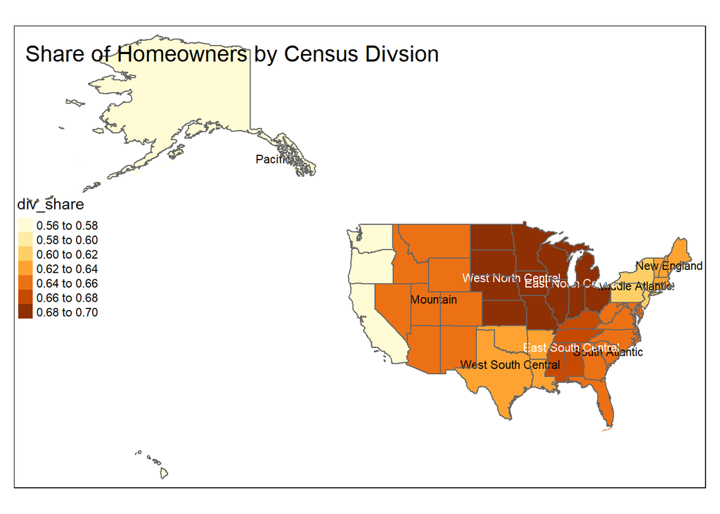

```r
# Merge census divisions shape data
map_housing_tenure <- division %>%
  left_join(housing_tenure, by = c("GEOID" = "DIVISION"))

tm_shape(state) + tm_borders() +
  tm_layout(title = "Share of Homeowners by Census Divsion",
            legend.position = c("LEFT", "center")) +
  tm_shape(map_housing_tenure) + tm_fill("div_share") + tm_text("NAME", size = 0.7) +
  tm_shape(state) + tm_borders()
```

Midwestern region (west North Central and East North Central) has very high rates of homeowners and this wanes out as going outwards. Coastal areas have lower incidences of homeownership. This is probably because of the existence of more larger metropolitan cities and hotter housing markets. Costs of living could also be taken into account. Maybe also age differences. Younger people tend to live in bigger cities and rent homes as opposed to owning one.

```r
# Housing Tenure by Race
housing_tenure_race <- household_clean %>%
  filter(TENURE>0) %>%
  mutate(race_name = case_when(HHRACE == 1 ~"White",
                               HHRACE == 2 ~"Black",
                               HHRACE == 3 ~"Native American",
                               HHRACE == 4 ~"Asian",
                               HHRACE == 5 ~"Hawaiian/Pacific Islander",
                               HHRACE >= 6 ~"Multiracial")) %>%
  group_by(race_name, TENURE) %>%
  summarise(total_hh = sum(WEIGHT)) %>%
  group_by(race_name) %>%
  mutate(race_total = sum(total_hh),
         race_share = total_hh/race_total)
```

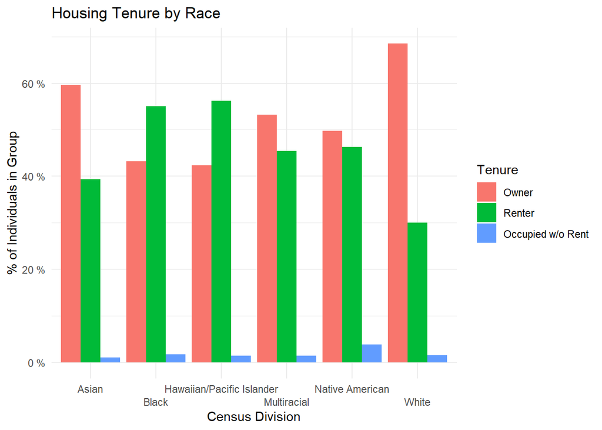

```r
# Race Bar plot
ggplot(housing_tenure_race, aes(x=race_name, y=race_share, fill = as.factor(TENURE))) +

  geom_col(position='dodge', stat='identity') +

  theme_minimal() +

  scale_y_continuous(labels = label_number(suffix = " %", scale = 100)) +

  scale_x_discrete(guide = guide_axis(n.dodge = 2)) +

  scale_fill_discrete(labels=c('Owner', 'Renter', 'Occupied w/o Rent')) +

  labs(title = "Housing Tenure by Race",
       x = "Census Division",
       y = "% of Individuals in Group",
       fill = "Tenure") +

  theme_minimal()
```

There is a clear disparity between homeownership rates within each racial group. Black and Hawaiian/Pacific Islanders have a larger renter share than homeowner vs all other groups. This is particualrly concerning as there could be some significant systematic barriers that affect these numbers.

```r
# Housing Tenure By Age Bracket
housing_tenure_age <- household_clean %>%
  filter(TENURE>0) %>%
  mutate(age_bracket= case_when(HHAGE < 25~"25 below",
                                HHAGE >= 25 & HHAGE <= 29~"25 to 29 years old",
                                HHAGE >= 30 & HHAGE <= 34~"30 to 34 years old",
                                HHAGE >= 35 & HHAGE <= 44~"35 to 44 years old",
                                HHAGE >= 45 & HHAGE <= 54~"45 to 54 years old",
                                HHAGE >= 55 & HHAGE <= 64~"55 to 64 years old",
                                HHAGE >= 65 & HHAGE <= 74~"65 to 74 years old",
                                HHAGE >= 75 ~ "75 and over")) %>%
  group_by(age_bracket, TENURE) %>%
  summarise(total_hh = sum(WEIGHT)) %>%
  group_by(age_bracket) %>%
  mutate(age_bracket_total = sum(total_hh),
         age_bracket_share = total_hh/age_bracket_total)
```

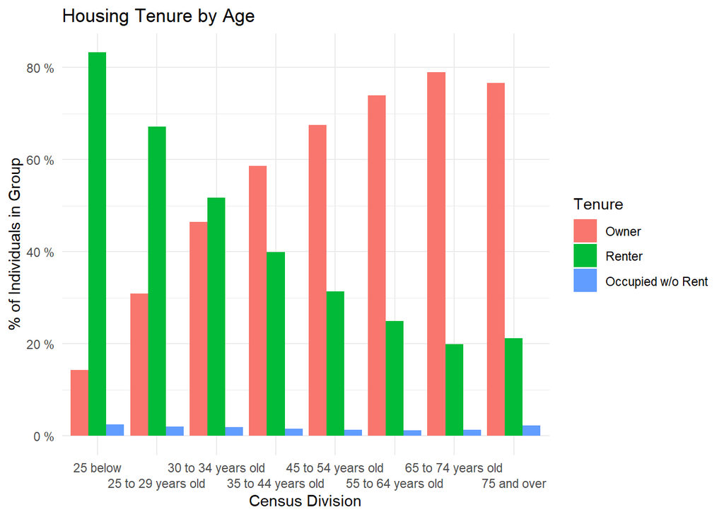

```r
# Age Bracket Bar plot
ggplot(housing_tenure_age, aes(x=age_bracket, y=age_bracket_share, fill = as.factor(TENURE))) +

  geom_col(position='dodge', stat='identity') +

  theme_minimal() +

  scale_y_continuous(labels = label_number(suffix = " %", scale = 100)) +

  scale_x_discrete(guide = guide_axis(n.dodge = 2)) +

  scale_fill_discrete(labels=c('Owner', 'Renter', 'Occupied w/o Rent')) +

  labs(title = "Housing Tenure by Age",
       x = "Census Division",
       y = "% of Individuals in Group",
       fill = "Tenure") +

  theme_minimal()
```

There is a clear positive relationship between homeownership and age. As age increases a larger share of the population owns homes. This makes sense as older people have had more time/chances of owning a home over time. If I had more time to do the project, I would have broken this down further to posibbly control for the time bias, maybe calculating age when they moved in instead of their current age. That would have other implications however and won’t exactly work in my regression.

```r
# Housing Tenure By INcome Bracket
housing_tenure_income <- household_clean %>%
  filter(TENURE>0) %>%
  mutate(income_bracket= case_when(HINCP < 5000~"$5k below",
                                HINCP >= 5000 & HINCP <= 9999~"$5k-$9999",
                                HINCP >= 10000 & HINCP <= 14999~"$10k-$14999",
                                HINCP >= 15000 & HINCP <= 19999~"$15k-$19999",
                                HINCP >= 20000 & HINCP <= 24999~"$20k-$24999",
                                HINCP >= 25000 & HINCP <= 29999~"$25k-$29999",
                                HINCP >= 30000 & HINCP <= 34999~"$30k-$34999",
                                HINCP >= 40000 & HINCP <= 49999~"$40k-$49999",
                                HINCP >= 50000 & HINCP <= 59999~"$50k-$59999",
                                HINCP >= 60000 & HINCP <= 79999~"$60k-$79999",
                                HINCP >= 80000 & HINCP <= 99999~"$80k-$99999",
                                HINCP >= 100000 & HINCP <= 119999~"$100k-$119999",
                                HINCP >= 120000 ~ "$120k over")) %>%
  group_by(income_bracket, TENURE) %>%
  summarise(total_hh = sum(WEIGHT), HINCP) %>%
  group_by(income_bracket) %>%
  mutate(income_bracket_total = sum(total_hh),
         income_bracket_share = total_hh/income_bracket_total)
```

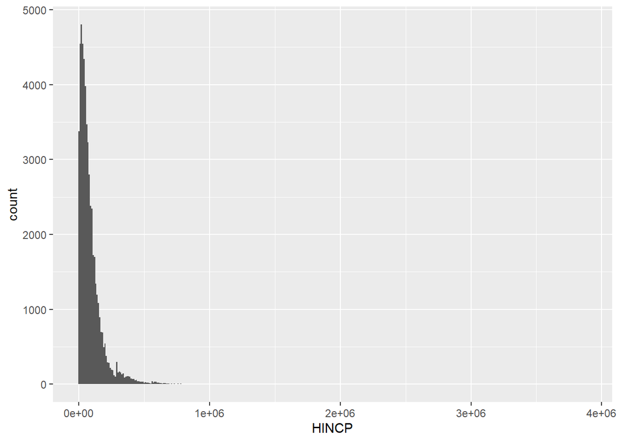

```r
ggplot(household_clean, aes(x=HINCP, fill = TENURE))+
  geom_histogram(binwidth = 10000)
```

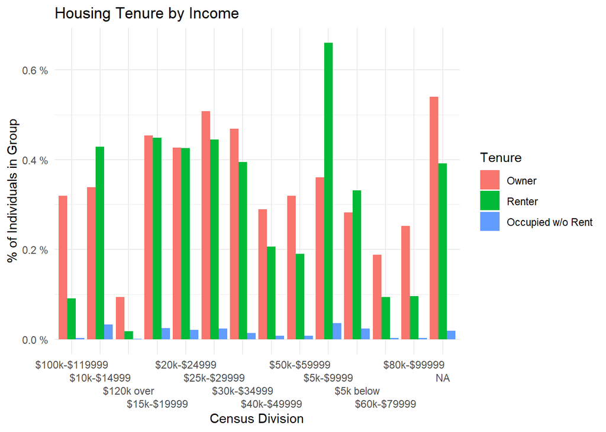

```r
# Age Bracket Bar plot
ggplot(housing_tenure_income, aes(x=income_bracket, y=income_bracket_share, fill = as.factor(TENURE))) +

  geom_col(position='dodge', stat='identity') +

  theme_minimal() +

  scale_y_continuous(labels = label_number(suffix = " %", scale = 1e3)) +

  scale_x_discrete(guide = guide_axis(n.dodge = 4)) +

  scale_fill_discrete(labels=c('Owner', 'Renter', 'Occupied w/o Rent')) +

  labs(title = "Housing Tenure by Income",
       x = "Census Division",
       y = "% of Individuals in Group",
       fill = "Tenure") +

  theme_minimal()
```

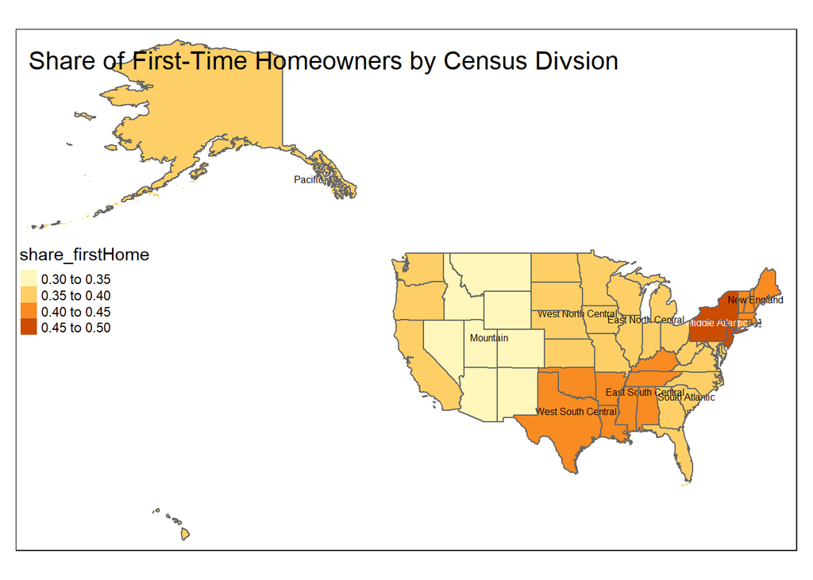

```r
# Share of first time homeowners (INTSTATUS 1 and TENURE 1)
total_homeowner <- housing_tenure %>%
  filter(TENURE==1) %>%
  group_by(DIVISION) %>%
  summarise(total_ind)

first_home <- household_clean %>%
  mutate(DIVISION = as.character(DIVISION)) %>%
  filter(TENURE == 1 & FIRSTHOME == 1) %>%
  group_by(DIVISION) %>%
  summarise(first_home_total = sum(WEIGHT)) %>%
  left_join(total_homeowner, by = "DIVISION") %>%
  mutate(share_firstHome = first_home_total/total_ind)

# Merge census divisions shape data with first_ho_count
map_first_home <- division %>%
  left_join(first_home, by = c("GEOID" = "DIVISION"))

tm_shape(state) + tm_borders() +
  tm_layout(title = "Share of First-Time Homeowners by Census Divsion",
            legend.position = c("LEFT", "center")) +
  tm_shape(map_first_home) + tm_fill("share_firstHome") + tm_text("NAME", size = 0.5) +
  tm_shape(state) + tm_borders()
```

This was my initial visualization shared in class. The South and Northeast have the highest share of First Time Homeowners. I wasn’t able to explore further, but breaking this down even more by recent homeowner would also be useful to understanding the geographical relationships and possibly market-value relationships.

I initially wanted to do a regression and explore different finance-related relationships to first time homeownership. This did not work out since any data to estimate debt is only available on homeowners and not on renter and other tenures.

```r
# Some cleaning for regression
household_reg <- household_clean %>%
  filter(INTSTATUS==1) %>%
  # Create indicator variables for homeowner, race, higher ed attainment
  mutate(homeowner = ifelse(TENURE==1, 1, 0),
         black = ifelse(HHRACE == 2 ,1,0),
         native = ifelse(HHRACE==3, 1, 0),
         asian = ifelse(HHRACE==4, 1, 0),
         haw_pacific = ifelse(HHRACE==4, 1, 0),
         multiracial = ifelse(HHRACE>=6, 1, 0),
         race = ifelse(HHRACE >=6, 6, HHRACE),
         higher_ed = ifelse(HHGRAD>=44, 1, 0),
         tenure = ifelse(TENURE==1, 1, 0))

# Homeownership count by income
inc_homeowner_count <- household_reg %>%
  mutate(DIVISION = as.character(DIVISION)) %>%
  filter(TENURE>0) %>%
  group_by(HINCP, tenure) %>%
  summarise(total_tenure=n()) %>%
  mutate(tenure_1 = ifelse(tenure==1,total_tenure,0),
         tenure_0 = ifelse(tenure==0,total_tenure,0)) %>%
  group_by(HINCP) %>%
  summarise(tenure_1= sum(tenure_1),
            tenure_0 = sum(tenure_0),
            total = tenure_1+tenure_0) %>%
  mutate(logit_own=log(tenure_1/tenure_0)) %>%
  filter(is.finite(logit_own))
```

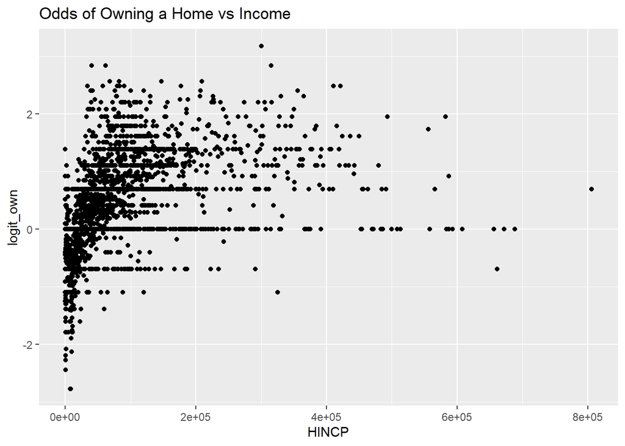

```r
# Looking at relationship between income and odds of owning a home
ggplot(inc_homeowner_count, aes(x=HINCP, y=logit_own)) + geom_point() +
  labs(title = "Odds of Owning a Home vs Income")
```

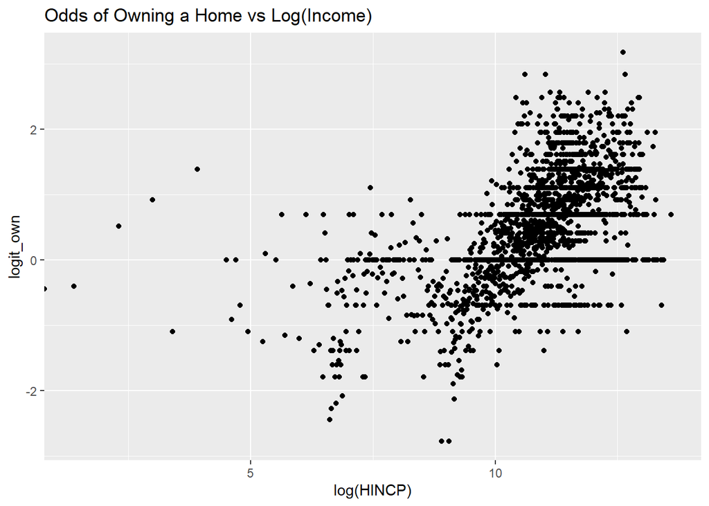

```r
ggplot(inc_homeowner_count, aes(x=log(HINCP), y=logit_own)) + geom_point() +
  labs(title = "Odds of Owning a Home vs Log(Income)")
```

```r
# Log Income Model
log_household <- household_reg %>%
  mutate(log_income = log(HINCP)) %>%
  filter(is.finite(log_income))
model1<- glm(tenure~log_income+black+haw_pacific+HHAGE+higher_ed, data = log_household, family = "binomial")
```

# Regression Results

Prior to regressing I first plotted a logit plot of income vs odds of homeownership to see if income is an appropriate predictor. Using the nominal income, it shows that there is a curved relationship. To fix this, I transformed income to log(income) and replotted. The second odds of homeownership vs log(income) plot shows linearity.

```r
exp(0.7539/100)
```

```
## [1] 1.007567
```

```r
exp(-0.7613)
```

```
## [1] 0.4670589
```

```r
exp(0.3702)
```

```
## [1] 1.448024
```

# Conclusion

My exploration of this dataset would have been more helpful if I had a deeper understanding of homeownership itself. My chosen analysis and variables were only ones I intuitively knew. I would have loved to do a deep dive and spend more time cleaning my dataset to create the appropriate variables. As mentioned in the previous section, having even more household finance data and control variables would possibly stem better estimates.

There are over a thousand different variables to explore on and a few hundred of those are just household characteristics. For example, as I was making the map on first time homeownership, I realized that this data could span an analysis on the group make-up to behaviors comparisons with experienced homeowners. With more understanding of regression methods and curiosity towards the subject area, working data like this could create some really profound estimates and analyses.